> **Tip**: Welcome to the Investigate a Dataset project! You will find tips in quoted sections like this to help organize your approach to your investigation. Before submitting your project, it will be a good idea to go back through your report and remove these sections to make the presentation of your work as tidy as possible. First things first, you might want to double-click this Markdown cell and change the title so that it reflects your dataset and investigation.

# Project: No Show Appointments Data Analysis

- Introduction
- Data Wrangling
- Exploratory Data Analysis
- Conclusions

## Introduction

In this project, We are going to analyzing [No-Show Appointment](https://www.google.com/url?q=https://d17h27t6h515a5.cloudfront.net/topher/2017/October/59dd2e9a_noshowappointments-kagglev2-may-2016/noshowappointments-kagglev2-may-2016.csv&sa=D&ust=1532469042118000) dataset. This dataset collects information from 100k medical appointments in Brazil and is focused on the question of whether or not patients show up for their appointment. A number of characteristics about the patient are included in each row.

The Dataset on Kaggel: [Medical Appointment No Shows](https://www.kaggle.com/joniarroba/noshowappointments)

- 'ScheduledDay' tells us on what day the patient set up their appointment.
- 'Neighborhood' indicates the location of the hospital.
- 'Scholarship' indicates whether or not the patient is enrolled in Brasilian welfare program.
- 'No-show' it says ‘No’ if the patient showed up to their appointment, and ‘Yes’ if they did not show up.

**Questions**: We're going to find:

- "What are most common reasons for patients for not showing up in thier appointments?"
- "Which factors affect showing up in appointments?"

```python
import pandas as pd
import matplotlib.pyplot as plt
import numpy as np
import seaborn as sb

from pandas.plotting import scatter_matrix
import matplotlib.ticker as ticker

%matplotlib inline
```

## Data Wrangling

> **Tip**: In this section of the report, you will load in the data, check for cleanliness, and then trim and clean your dataset for analysis. Make sure that you document your steps carefully and justify your cleaning decisions.

### General Properties

Read noshowappointments

```python
df = pd.read_csv('data/noshowappointments.csv')
df.head()
```

|  | PatientId | AppointmentID | Gender | ScheduledDay | AppointmentDay | Age | Neighbourhood | Scholarship | Hipertension | Diabetes | Alcoholism | Handcap | SMS_received | No-show |
| --- | --- | --- | --- | --- | --- | --- | --- | --- | --- | --- | --- | --- | --- | --- |
| 0 | 2.987250e+13 | 5642903 | F | 2016-04-29T18:38:08Z | 2016-04-29T00:00:00Z | 62 | JARDIM DA PENHA | 0 | 1 | 0 | 0 | 0 | 0 | No |
| 1 | 5.589978e+14 | 5642503 | M | 2016-04-29T16:08:27Z | 2016-04-29T00:00:00Z | 56 | JARDIM DA PENHA | 0 | 0 | 0 | 0 | 0 | 0 | No |
| 2 | 4.262962e+12 | 5642549 | F | 2016-04-29T16:19:04Z | 2016-04-29T00:00:00Z | 62 | MATA DA PRAIA | 0 | 0 | 0 | 0 | 0 | 0 | No |
| 3 | 8.679512e+11 | 5642828 | F | 2016-04-29T17:29:31Z | 2016-04-29T00:00:00Z | 8 | PONTAL DE CAMBURI | 0 | 0 | 0 | 0 | 0 | 0 | No |
| 4 | 8.841186e+12 | 5642494 | F | 2016-04-29T16:07:23Z | 2016-04-29T00:00:00Z | 56 | JARDIM DA PENHA | 0 | 1 | 1 | 0 | 0 | 0 | No |

```python
df.shape
```

```
(110527, 14)
```

```python
df.describe()
```

|  | PatientId | AppointmentID | Age | Scholarship | Hipertension | Diabetes | Alcoholism | Handcap | SMS_received |
| --- | --- | --- | --- | --- | --- | --- | --- | --- | --- |
| count | 1.105270e+05 | 1.105270e+05 | 110527.000000 | 110527.000000 | 110527.000000 | 110527.000000 | 110527.000000 | 110527.000000 | 110527.000000 |
| mean | 1.474963e+14 | 5.675305e+06 | 37.088874 | 0.098266 | 0.197246 | 0.071865 | 0.030400 | 0.022248 | 0.321026 |
| std | 2.560949e+14 | 7.129575e+04 | 23.110205 | 0.297675 | 0.397921 | 0.258265 | 0.171686 | 0.161543 | 0.466873 |
| min | 3.921784e+04 | 5.030230e+06 | -1.000000 | 0.000000 | 0.000000 | 0.000000 | 0.000000 | 0.000000 | 0.000000 |
| 25% | 4.172614e+12 | 5.640286e+06 | 18.000000 | 0.000000 | 0.000000 | 0.000000 | 0.000000 | 0.000000 | 0.000000 |
| 50% | 3.173184e+13 | 5.680573e+06 | 37.000000 | 0.000000 | 0.000000 | 0.000000 | 0.000000 | 0.000000 | 0.000000 |
| 75% | 9.439172e+13 | 5.725524e+06 | 55.000000 | 0.000000 | 0.000000 | 0.000000 | 0.000000 | 0.000000 | 1.000000 |
| max | 9.999816e+14 | 5.790484e+06 | 115.000000 | 1.000000 | 1.000000 | 1.000000 | 1.000000 | 4.000000 | 1.000000 |

```python
df.info()
```

```
<class 'pandas.core.frame.DataFrame'>
RangeIndex: 110527 entries, 0 to 110526
Data columns (total 14 columns):
PatientId         110527 non-null float64
AppointmentID     110527 non-null int64
Gender            110527 non-null object
ScheduledDay      110527 non-null object
AppointmentDay    110527 non-null object
Age               110527 non-null int64
Neighbourhood     110527 non-null object
Scholarship       110527 non-null int64
Hipertension      110527 non-null int64
Diabetes          110527 non-null int64
Alcoholism        110527 non-null int64
Handcap           110527 non-null int64
SMS_received      110527 non-null int64
No-show           110527 non-null object
dtypes: float64(1), int64(8), object(5)
memory usage: 11.8+ MB
```

```python
df.isna().sum()
```

```
PatientId         0
AppointmentID     0
Gender            0
ScheduledDay      0
AppointmentDay    0
Age               0
Neighbourhood     0
Scholarship       0
Hipertension      0
Diabetes          0
Alcoholism        0
Handcap           0
SMS_received      0
No-show           0
dtype: int64
```

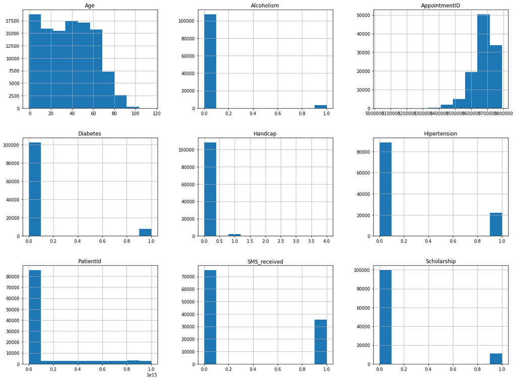

```python
df.hist(figsize=(20,15));
```

> **Tip**: You should *not* perform too many operations in each cell. Create cells freely to explore your data. One option that you can take with this project is to do a lot of explorations in an initial notebook. These don't have to be organized, but make sure you use enough comments to understand the purpose of each code cell. Then, after you're done with your analysis, create a duplicate notebook where you will trim the excess and organize your steps so that you have a flowing, cohesive report.

> **Tip**: Make sure that you keep your reader informed on the steps that you are taking in your investigation. Follow every code cell, or every set of related code cells, with a markdown cell to describe to the reader what was found in the preceding cell(s). Try to make it so that the reader can then understand what they will be seeing in the following cell(s).

### Data Cleaning (Drop invalid, outliers & duplicated values, Change types, Rename columns & Delete unimportant columns)

#### Rename columns

```python
df['SMSReceived'] = df['SMS_received']
df['NoShow'] = df['No-show']
```

#### Delete unimportant columns

```python
df.drop(['PatientId', 'AppointmentID','SMS_received', 'No-show'], axis=1 ,inplace=True)
```

```python
df.info()
```

```
<class 'pandas.core.frame.DataFrame'>
RangeIndex: 110527 entries, 0 to 110526
Data columns (total 12 columns):
Gender            110527 non-null object
ScheduledDay      110527 non-null object
AppointmentDay    110527 non-null object
Age               110527 non-null int64
Neighbourhood     110527 non-null object
Scholarship       110527 non-null int64
Hipertension      110527 non-null int64
Diabetes          110527 non-null int64
Alcoholism        110527 non-null int64
Handcap           110527 non-null int64
SMSReceived       110527 non-null int64
NoShow            110527 non-null object
dtypes: int64(7), object(5)
memory usage: 10.1+ MB
```

#### Drop invalid values

As Age can't be negative value, its better to cut negative values of age of the dataset

```python
negative_age = df[df.Age < 0].index
negative_age
```

```
Int64Index([99832], dtype='int64')
```

```python
df.drop(negative_age ,inplace=True)
```

```python
sum(df.Age < 0)
```

```
0
```

#### Drop duplicated values

```python
sum(df.duplicated())
```

```
635
```

As Duplicatied data would manipulate the insights, its better to drop them from the dataset

```python
df.drop_duplicates(inplace=True)
```

```python
df.info()
```

```
<class 'pandas.core.frame.DataFrame'>
Int64Index: 109891 entries, 0 to 110526
Data columns (total 12 columns):
Gender            109891 non-null object
ScheduledDay      109891 non-null object
AppointmentDay    109891 non-null object
Age               109891 non-null int64
Neighbourhood     109891 non-null object
Scholarship       109891 non-null int64
Hipertension      109891 non-null int64
Diabetes          109891 non-null int64
Alcoholism        109891 non-null int64
Handcap           109891 non-null int64
SMSReceived       109891 non-null int64
NoShow            109891 non-null object
dtypes: int64(7), object(5)
memory usage: 10.9+ MB
```

#### Drop outliers

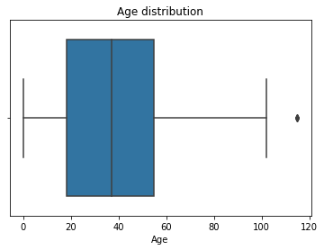

```python
sb.boxplot(df.Age).set_title('Age distribution')
plt.show()
```

```python
df[(df.Age > 100)]
```

|  | Gender | ScheduledDay | AppointmentDay | Age | Neighbourhood | Scholarship | Hipertension | Diabetes | Alcoholism | Handcap | SMSReceived | NoShow |
| --- | --- | --- | --- | --- | --- | --- | --- | --- | --- | --- | --- | --- |
| 58014 | F | 2016-05-03T09:14:53Z | 2016-05-03T00:00:00Z | 102 | CONQUISTA | 0 | 0 | 0 | 0 | 0 | 0 | No |
| 63912 | F | 2016-05-16T09:17:44Z | 2016-05-19T00:00:00Z | 115 | ANDORINHAS | 0 | 0 | 0 | 0 | 1 | 0 | Yes |
| 68127 | F | 2016-04-08T14:29:17Z | 2016-05-16T00:00:00Z | 115 | ANDORINHAS | 0 | 0 | 0 | 0 | 1 | 0 | Yes |
| 76284 | F | 2016-05-30T09:44:51Z | 2016-05-30T00:00:00Z | 115 | ANDORINHAS | 0 | 0 | 0 | 0 | 1 | 0 | No |
| 90372 | F | 2016-05-31T10:19:49Z | 2016-06-02T00:00:00Z | 102 | MARIA ORTIZ | 0 | 0 | 0 | 0 | 0 | 0 | No |
| 97666 | F | 2016-05-19T07:57:56Z | 2016-06-03T00:00:00Z | 115 | SÃO JOSÉ | 0 | 1 | 0 | 0 | 0 | 1 | No |

```python
df = df[(df.Age < 100)]
```

- Cut off patients of age>100 as they are outliers

#### Change types

```python
df['AppointmentDay'] = pd.to_datetime(df['AppointmentDay']).dt.date
df['ScheduledDay'] = pd.to_datetime(df['ScheduledDay']).dt.date
```

Remove appointments was set before reserved day

```python
df = df[df['AppointmentDay'] >= df['ScheduledDay']]
df.shape
```

```
(109877, 12)
```

```python
df['IsShowed'] = (df.NoShow == "Yes").astype(int)
```

```python
df.info()
```

```
<class 'pandas.core.frame.DataFrame'>
Int64Index: 109877 entries, 0 to 110526
Data columns (total 13 columns):
Gender            109877 non-null object
ScheduledDay      109877 non-null object
AppointmentDay    109877 non-null object
Age               109877 non-null int64
Neighbourhood     109877 non-null object
Scholarship       109877 non-null int64
Hipertension      109877 non-null int64
Diabetes          109877 non-null int64
Alcoholism        109877 non-null int64
Handcap           109877 non-null int64
SMSReceived       109877 non-null int64
NoShow            109877 non-null object
IsShowed          109877 non-null int64
dtypes: int64(8), object(5)
memory usage: 11.7+ MB
```

## Exploratory Data Analysis

> **Tip**: Now that you've trimmed and cleaned your data, you're ready to move on to exploration. Compute statistics and create visualizations with the goal of addressing the research questions that you posed in the Introduction section. It is recommended that you be systematic with your approach. Look at one variable at a time, and then follow it up by looking at relationships between variables.

### Research Question 1 (Calculate percentages)

```python
def calculate_percent(df_last_ver, column_name, column_value, txt):
    count = df_last_ver[(df_last_ver[column_name]== column_value)][column_name].count()
    percent = (count / df_last_ver[column_name].count()) *100
    print('{t} percentage = {p:.2f} %'.format(t=txt, p=percent))
```

```python
calculate_percent(df,'NoShow','No', 'Showed patients')
calculate_percent(df,'NoShow','Yes', 'Never showed patients')
```

```
Showed patients percentage = 79.89 %
Never showed patients percentage = 20.11 %
```

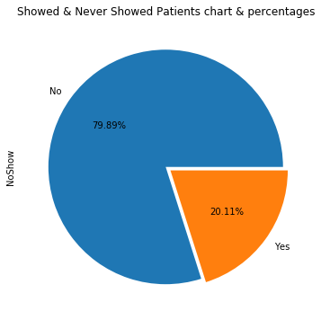

```python
df.NoShow.value_counts().plot.pie(figsize=(6,6), autopct='%.2f%%', explode=(0, .05))
plt.title('Showed & Never Showed Patients chart & percentages')
plt.show()
```

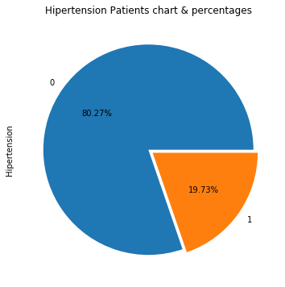

```python
df.Hipertension.value_counts().plot.pie(figsize=(6,6), autopct='%.2f%%', explode=(0, .05))
plt.title('Hipertension Patients chart & percentages')
plt.show()
```

- Patients who have Hipertension percentage = 19.73 %
- Patients who don't have Hipertension percentage = 80.27 %

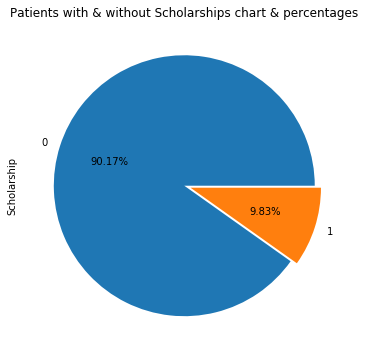

```python
df.Scholarship.value_counts().plot.pie(figsize=(6,6), autopct='%.2f%%', explode=(0, .05))
plt.title('Patients with & without Scholarships chart & percentages')
plt.show()
```

- 90% of patients doesn't have scholarship
- ~10% of patients have scholarship

### Research Question 2 (Analyze relations between Age, Neighbourhood, Scholarship & Not showing in appointment)

```python
def value_to_class(value):
    if value < 4:
        return 1          #Baby
    elif value < 13:
        return 2          #Child
    elif value < 21:
        return 3          #Tean
    elif value < 35:
        return 4          #Young adult
    elif value < 60:
        return 5          #Adult
    else:
        return 6          #Elder

age_dict = {
    1:'Baby',
    2:'Child',
    3:'Teen',
    4:'Young adult',
    5:'Adult',
    6:'Elder',
}
```

```python
df['AgeClass'] = df['Age'].apply(value_to_class)
```

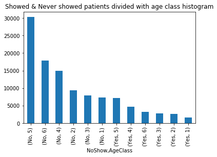

```python
df.groupby('NoShow').AgeClass.value_counts().plot(kind='bar')
plt.title('Showed & Never showed patients divided with age class histogram');
```

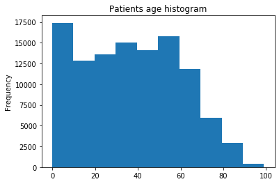

```
average age of all patients: 37.08
```

```python
df.Age.plot.hist()
plt.title('Patients age histogram')
plt.show();
print('average age of all patients: {:.2f}'.format(df.Age.mean()))
```

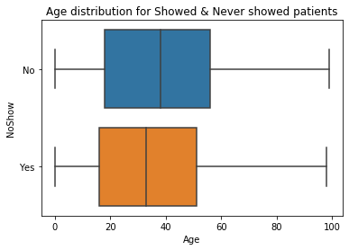

```python
sb.boxplot( x=df.Age, y=df.NoShow)
plt.title('Age distribution for Showed & Never showed patients')
plt.show()
```

- Some Patients who never show in appointments are from age ~= 20:50

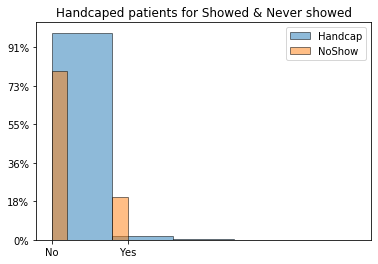

```python
fig, ax = plt.subplots()
ax.hist(df['Handcap'], bins=5, edgecolor='black', label='Handcap', alpha = 0.5)
ax.hist(df['NoShow'], bins=5, edgecolor='black', label='NoShow', alpha =0.5)

ax.yaxis.set_major_formatter(ticker.PercentFormatter(xmax=len(df)))

plt.title('Handcaped patients for Showed & Never showed')
plt.legend();
```

- Number of **Handcaped** Patients who **Never Show** in Appointments are **very small** compared with **none handcapes** patients who **showed** in their appointments

[figure not shown]

```python
showed = (df.NoShow == 'No')
neverShowed = (df.NoShow == 'Yes')

df.Neighbourhood[showed].hist(alpha=0.5, bins=20, label='showed')
df.Neighbourhood[neverShowed].hist(alpha=0.5, bins=20, label='neverShowed')
plt.title('Showed & Never showed patients according to population distribution')
plt.legend();
```

```python
df[(df['NoShow']== 'Yes')]['Neighbourhood'].value_counts()
```

```
JARDIM CAMBURI                 1429
MARIA ORTIZ                    1219
ITARARÉ                         902
RESISTÊNCIA                     884
JESUS DE NAZARETH               695
                               ...
PONTAL DE CAMBURI                12
ILHA DO BOI                       3
ILHAS OCEÂNICAS DE TRINDADE       2
ILHA DO FRADE                     2
AEROPORTO                         1
Name: Neighbourhood, Length: 80, dtype: int64
```

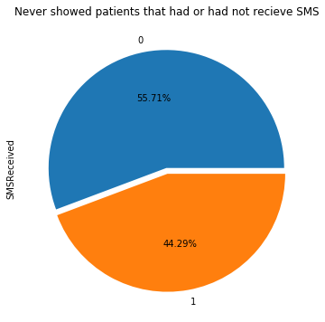

```python
df[(df['NoShow']== 'Yes')]['SMSReceived'].value_counts().plot.pie(figsize=(6,6), autopct='%.2f%%', explode=(0, .05))
plt.title('Never showed patients that had or had not recieve SMS')
plt.show()
```

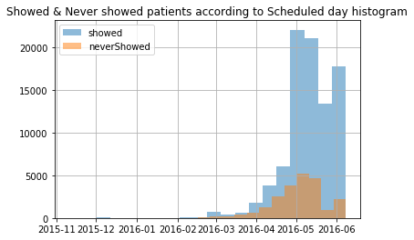

```python
df.ScheduledDay[showed].hist(alpha=0.5, bins=20, label='showed')
df.ScheduledDay[neverShowed].hist(alpha=0.5, bins=20, label='neverShowed')
plt.title('Showed & Never showed patients according to Scheduled day histogram')
plt.legend();
```

- **Some ScheduledDay** have **high numbers** of patients who **never show** in appointments than the others, for instance: period of **May 2016**

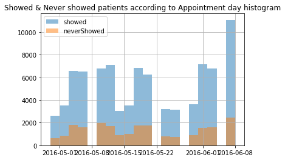

```python
df.AppointmentDay[showed].hist(alpha=0.5, bins=20, label='showed')
df.AppointmentDay[neverShowed].hist(alpha=0.5, bins=20, label='neverShowed')
plt.title('Showed & Never showed patients according to Appointment day histogram')
plt.legend();
```

- **Some AppointmentDay** have **high numbers** of patients who **never show** in appointments than the others, such as people who registered their appointment in **June 2016**

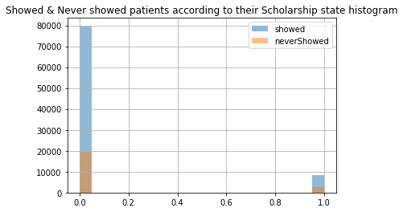

```python
df.Scholarship[showed].hist(alpha=0.5, bins=20, label='showed')
df.Scholarship[neverShowed].hist(alpha=0.5, bins=20, label='neverShowed')
plt.title('Showed & Never showed patients according to their Scholarship state histogram')
plt.legend();
```

```python
df.groupby('NoShow').Scholarship.value_counts()
```

```
NoShow  Scholarship
No      0              79541
        1               8245
Yes     0              19535
        1               2556
Name: Scholarship, dtype: int64
```

> **Tip**: Finally, summarize your findings and the results that have been performed. Make sure that you are clear with regards to the limitations of your exploration. If you haven't done any statistical tests, do not imply any statistical conclusions. And make sure you avoid implying causation from correlation!

> **Tip**: Once you are satisfied with your work, you should save a copy of the report in HTML or PDF form via the **File** > **Download as** submenu. Before exporting your report, check over it to make sure that the flow of the report is complete. You should probably remove all of the "Tip" quotes like this one so that the presentation is as tidy as possible. Congratulations!